# QTM 150 Final Project

Yash Dayal, Mario Sanchez del Campo, Carol Zhou, Alex Issokson

12/10/2021

##Part A ###1. Our group would like to investigate the efficiency of Delta flights to 3 different airports in New York (JFK, LGA, and EWR) from Atlanta in 2019 and 2020. This information will be helpful for anyone who wants to choose which airport they will get to the fastest. To calculate efficiency, we will use a proxy value obtained by dividing distance by total air time.

```r
airport<-read.csv("Top5airportsUS.csv",stringsAsFactors=T)

library(dplyr)
```

```r
library(ggplot2)

str(airport)
```

```
## 'data.frame':    2504429 obs. of  16 variables:
##  $ year          : int  2019 2019 2019 2019 2019 2019 2019 2019 2019 2019 ...
##  $ month         : int  1 1 1 1 1 1 1 1 1 1 ...
##  $ day           : int  1 1 1 1 1 1 1 1 1 1 ...
##  $ dep_time      : int  2 3 5 7 14 15 15 16 17 18 ...
##  $ sched_dep_time: int  2359 2359 2350 2359 2350 2359 2359 2359 2335 15 ...
##  $ dep_delay     : int  3 4 15 8 24 16 16 17 42 3 ...
##  $ arr_time      : int  543 504 723 522 514 333 346 113 306 807 ...
##  $ sched_arr_time: int  549 459 700 535 517 327 334 103 232 810 ...
##  $ arr_delay     : int  -6 5 23 -13 -3 6 12 10 34 -3 ...
##  $ carrier       : Factor w/ 17 levels "9E","AA","AS",..: 14 2 2 4 7 2 2 2 3 2 ...
##  $ flight        : int  2306 2319 1035 83 153 1473 1483 1266 1011 317 ...
##  $ tailnum       : Factor w/ 6001 levels "215NV","216NV",..: 3651 5397 5025 5986 875 5965 5792 4099 2475 5947 ...
##  $ origin        : Factor w/ 5 levels "ATL","DEN","DFW",..: 4 4 4 2 2 3 3 3 4 4 ...
##  $ dest          : Factor w/ 297 levels "ABE","ABI","ABQ",..: 210 79 16 149 218 176 186 227 255 186 ...
##  $ air_time      : int  197 148 226 173 157 117 133 153 143 255 ...
##  $ distance      : int  1744 1235 1947 1626 1558 985 1121 1126 954 2342 ...
```

```r
ATL_DL_NY<-airport %>%
  filter(origin=="ATL") %>%
  filter(carrier=="DL") %>%
  filter(dest=="JFK"|dest=="LGA"|dest=="EWR") %>%
  mutate(efficiency=distance/air_time)
```

###2. Our response variable is efficiency. The distribution shape is slightly left skewed and almost normal. We chose efficiency because we believed that effiency would change with the year because of COVID-19 between 2019 and 2020.

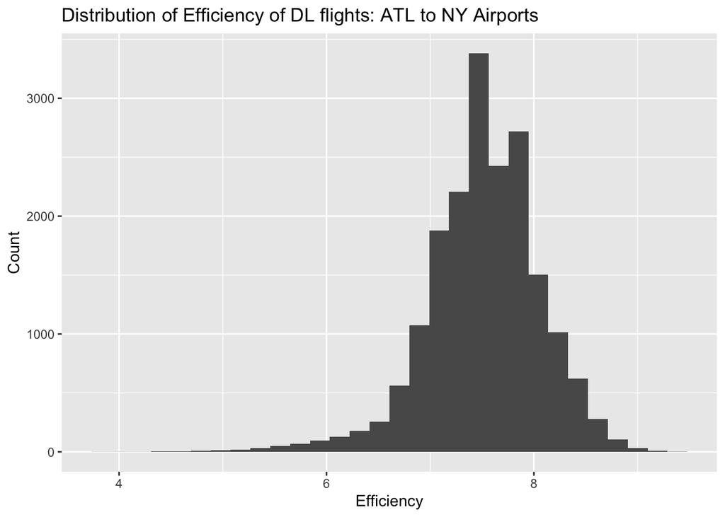

```r
#A
ggplot(ATL_DL_NY,aes(efficiency)) +
  geom_histogram() + labs(x = "Efficiency", y = "Count", title = "Distribution of Efficiency of DL flights: ATL to NY Airports")
```

```r
#B
summary(ATL_DL_NY$efficiency)
```

```
##    Min. 1st Qu.  Median    Mean 3rd Qu.    Max.    NA's
##   3.829   7.238   7.535   7.519   7.856   9.383     392
```

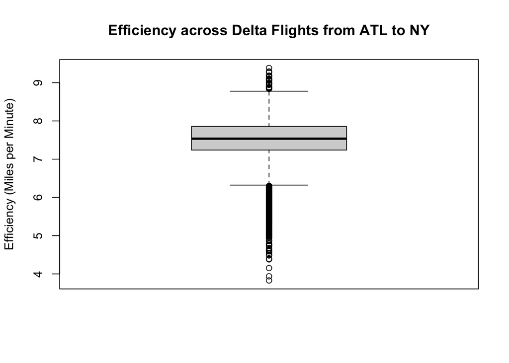

```r
#C
boxplot(ATL_DL_NY$efficiency, ylab = "Efficiency (Miles per Minute)", main = "Efficiency across Delta Flights from ATL to NY")
```

```r
 # ggplot(ATL_DL_NY,aes(efficiency))+
  #geom_boxplot() - if we make the boxplot through GGplot
```

###3. Lower bound = 6.311 Upper bound = 8.783 It seems like the year has an impact on the efficiency of the flight. Most of the outlier data seems to be from the year 2019 where majority of the delayed flights come from 2019. Most of the outlier data that exceeds the upper fence (meaning these flights were more efficient than normal) are from the year 2020. According to the prop.table, it seems like across both years 2020 and 2019, LGA receives the most amount of unusually fast or unusually slow flights.

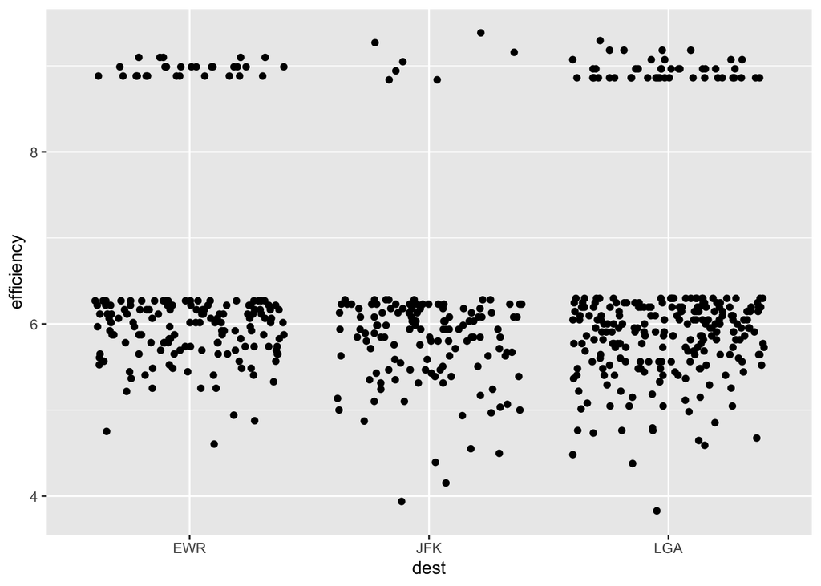

```r
LeftFence = 7.238-1.5*(7.856-7.238)
RightFence = 7.856+1.5*(7.856-7.238)

unusual<-ATL_DL_NY %>%
  filter(efficiency<=LeftFence|efficiency>=RightFence)

ggplot(unusual,aes(dest,efficiency))+
  geom_jitter()
```

```r
table(droplevels(unusual$dest),unusual$year)
```

```
##
##       2019 2020
##   EWR  126   49
##   JFK  114   23
##   LGA  209   67
```

```r
prop.table(table(droplevels(unusual$dest),unusual$year))
```

```
##
##             2019       2020
##   EWR 0.21428571 0.08333333
##   JFK 0.19387755 0.03911565
##   LGA 0.35544218 0.11394558
```

###4. Our main explanatory variable is destination.

1. Given our setup, we wanted to see which NY airport destination would be the fastest/most efficient.
2. Destination almost perfectly determines distance, and distance in turn determines air time, and both of these determine our proxy value of efficiency.

```r
table(droplevels(ATL_DL_NY$dest))
```

```
##
##  EWR  JFK  LGA
## 6049 4596 8431
```

```r
table(droplevels(ATL_DL_NY$dest),ATL_DL_NY$year)
```

```
##
##       2019 2020
##   EWR 3780 2269
##   JFK 2769 1827
##   LGA 5457 2974
```

###6.

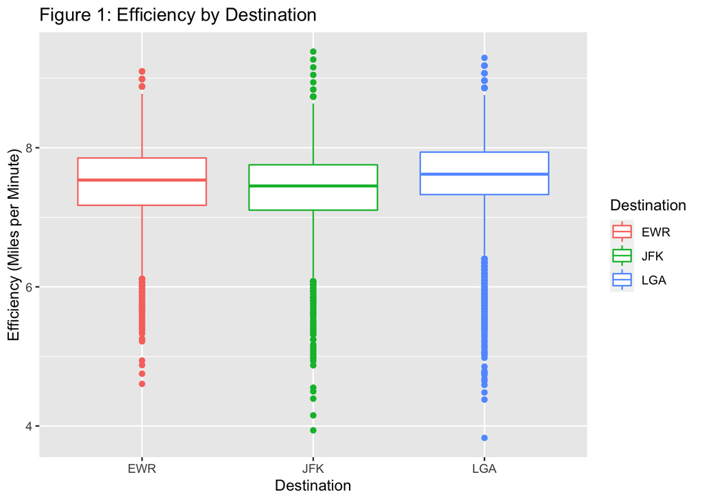

```r
ggplot(ATL_DL_NY,aes(dest,efficiency))+
  geom_boxplot(aes(color=dest))+
  labs(x="Destination",y="Efficiency (Miles per Minute)", color="Destination"
       ,title="Figure 1: Efficiency by Destination")
```

###7. The box plot shows that while the medians are all very similar, the median for LGA is the highest, possibly indicating that it has the highest average efficiency. More evidence pointing towards this possibility is that LGA has more flights than both EWR and JFK. Similarly, JFK has the lowest median.

##Part B ###1. The second explanatory variable is year. Given that COVID-19 created all sorts of trouble for the airplane industry (such as in the form of delays, or cancellations), we wanted to see if it affected our result of efficiency in any way. 2020 possibly has higher efficiency than 2019 since less people travel.

###2.

```r
ATL_DL_NY2<-ATL_DL_NY %>%
  group_by(year,dest) %>%
  summarize(avg_efficiency=mean(efficiency,na.rm=T)) %>%
  arrange(desc(avg_efficiency))
summary(ATL_DL_NY2)
```

```
##       year           dest   avg_efficiency
##  Min.   :2019   EWR    :2   Min.   :7.300
##  1st Qu.:2019   JFK    :2   1st Qu.:7.443
##  Median :2020   LGA    :2   Median :7.544
##  Mean   :2020   ABE    :0   Mean   :7.533
##  3rd Qu.:2020   ABI    :0   3rd Qu.:7.638
##  Max.   :2020   ABQ    :0   Max.   :7.734
##                 (Other):0
```

```r
ATL_DL_NY2
```

```
## # A tibble: 6 x 3
## # Groups:   year [2]
##    year dest  avg_efficiency
##   <int> <fct>          <dbl>
## 1  2020 LGA             7.73
## 2  2020 EWR             7.66
## 3  2020 JFK             7.57
## 4  2019 LGA             7.51
## 5  2019 EWR             7.42
## 6  2019 JFK             7.30
```

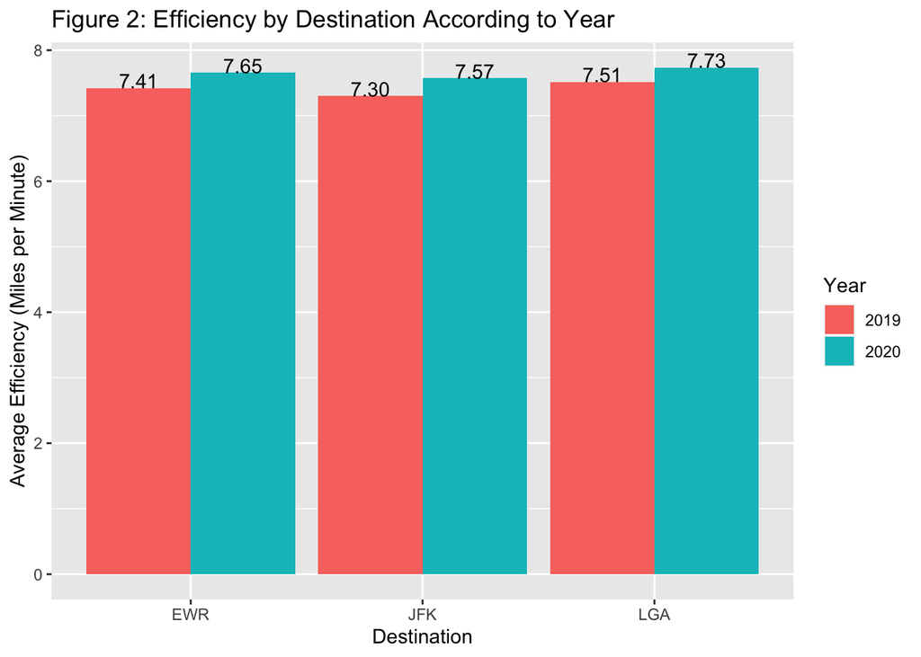

```r
ggplot(ATL_DL_NY2,aes(dest,avg_efficiency,group=factor(year)))+
  geom_col(aes(fill=factor(year)),position="dodge")+
  geom_text(
    aes(label=substr(avg_efficiency,1,4)),
    position=position_dodge(0.9),
    vjust=0) +
  labs(x="Destination",y="Average Efficiency (Miles per Minute)",fill="Year"
       ,title="Figure 2: Efficiency by Destination According to Year")
```

###3. This bar plot is much more useful than the box plot in part A because it clearly compares the average efficiency across airports, and then by year too. As suspected, in both 2019 and 2020, LGA has the highest efficiency, even if only by 0.1 and 0.08 in 2019 and 2020, respectively. While these results may not be practically significant (we would need to run a further statistical analysis to find out), the data suggests that LGA has the highest efficiency. This pattern also clearly shows that the efficiency is slightly higher by year as each airport’s efficiency increased by at least 0.22 units.

###4. This bar plot could be improved by accounting for delays as well as early arrivals. According to this plot, LGA may be the most efficient, but given they have more flights than the other airports, there could be many more delays. Furthermore, adding delays would help increase the gap between each of the averages, thus demonstrating a more reliable result. Any early arrival is shown by a negative delay in the dataset. Also, another alternative proxy value for efficiency could be calculating the delays per airport and relating that to the number of flights.

###5. This plot factors delays into account. We split the data into delayed and not delayed and then analyzed efficiency across year and airport.

```r
ATL_DL_NY$delay<-factor(ATL_DL_NY$dep_delay,levels=c("Not Delayed","Delayed"))
ATL_DL_NY$delay[ATL_DL_NY$dep_delay<=0]<-"Not Delayed"
ATL_DL_NY$delay[ATL_DL_NY$dep_delay>0]<-"Delayed"
table(ATL_DL_NY$delay)
```

```
##
## Not Delayed     Delayed
##       11307        7429
```

```r
#Removes the observations that have NAs.
sum(is.na(ATL_DL_NY$delay))
```

```
## [1] 340
```

```r
ATL_DL_No_NA<-ATL_DL_NY %>%
  filter(delay=="Not Delayed"|delay=="Delayed")

sum(is.na(ATL_DL_No_NA$delay))
```

```
## [1] 0
```

```r
ATL_DL_NY3<-ATL_DL_No_NA %>%
  group_by(year,dest,delay) %>%
  summarize(avg_efficiency=mean(efficiency,na.rm=T)) %>%
  arrange(desc(avg_efficiency))
ATL_DL_NY3
```

```
## # A tibble: 12 x 4
## # Groups:   year, dest [6]
##     year dest  delay       avg_efficiency
##    <int> <fct> <fct>                <dbl>
##  1  2020 LGA   Delayed               7.76
##  2  2020 LGA   Not Delayed           7.72
##  3  2020 EWR   Delayed               7.70
##  4  2020 EWR   Not Delayed           7.65
##  5  2020 JFK   Delayed               7.60
##  6  2020 JFK   Not Delayed           7.56
##  7  2019 LGA   Not Delayed           7.54
##  8  2019 LGA   Delayed               7.49
##  9  2019 EWR   Not Delayed           7.45
## 10  2019 EWR   Delayed               7.38
## 11  2019 JFK   Not Delayed           7.32
## 12  2019 JFK   Delayed               7.28
```

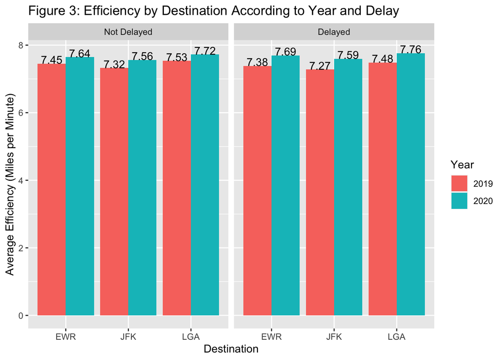

```r
ggplot(ATL_DL_NY3,aes(dest,avg_efficiency,group=factor(year))) +
  geom_col(aes(fill=factor(year)),position="dodge") +
  geom_text(
    aes(label=substr(avg_efficiency,1,4)),
    position=position_dodge(0.9),
    vjust=0) +
  facet_wrap(~delay) +
  labs(x="Destination",y="Average Efficiency (Miles per Minute)",fill="Year"
       ,title="Figure 3: Efficiency by Destination According to Year and Delay")
```

###6. Through this exploratory analysis, we have learned a few things. First, we have learned that flying to LGA from Atlanta is most likely to have the highest efficiency. Comparing LGA to the other airports, it has the highest efficiency in both 2019 and 2020. This is shown to be true with and without delays. Rather, we can note that in 2020, LGA has a higher efficiency with delays, which shows that they are more often early than late. Second, it is clear that flights in 2020 have a higher efficiency than those in 2019. Lastly, we can see that with delays, flights in 2019 are less efficient than those without delays while flights in 2020 are more efficient with delays than those without (again, implying that they are often early).